# Statistics - The Stroop Effect

Damian Brunold

Dezember 2015

## Introduction

The Stroop Effect is a famous psychology effect, that was first published in 1929 in Germany and first published in english in 1935 by John Ridley Stroop.[1]

The experiment works as follows: the subject is shown a list of words of colors, e.g. ‘red’, printed in colored inks. He or she has to name the color of the ink used to print each word. The time used is measured.

There are two conditions: the first one is named ‘congruent’ and here the color of the ink and the color denoted by the word match, i.e. the word ‘red’ is shown in red ink, the word ‘green’ is shown in green ink.

For example: red green blue

The second condition is called ‘incongruent’. Here, the color of the ink and the color denoted by the word do not match, e.g. ‘red’ is shown in blue ink.

For example: blue red green

The result of the experiment is that the time needed to complete the task is higher for the incongruent condition than for the congruent condition.

## Overview

The *independent variable* is the condition (congruent or incongruent word condition). The *dependent variable* is the time needed to complete the task.

*Null hypothesis:* The population mean of the time needed to complete the task is the same for congruent and incongruent word conditions.

$H_0: \mu_C = \mu_I$

*Alternative hypothesis:* The population mean of the time to complete the task is different for congruent and incongruent word conditions.

$H_{1}: \mu_C \neq \mu_I$

where $\mu_C$ is the population mean in case of the congruent condition and $\mu_I$ is the population mean in case of the incongruent condition.

We have two samples, one for each condition, and want to test whether there is a statistically significant difference between the means of the populations the samples are taken from.

Since we do not know the population standard deviation of either the congruent or the incongruent condition we cannot use the *z-test*. Also, we only have 24 observations whereas a *z-test* generally requires at least 30 observations.

From the experimental situation (independent, scalar observations) we can assume that the distributions likely are normal. We will strengthen this assumption by plotting a histogram of the distributions of our samples.

These considerations leads us to propose using the *t-test*. Since we do not know whether any difference would be positive or negative, we perform a two-sided t-test. And since we have paired values (for each subject one for congruent and one value for incongruent), we can perform a paired (dependent) t-test.

We choose as *significance level* $\alpha = 0.05$.

## Loading the data

First, we read the CSV file with the data.

```r
df <- read.csv("stroopdata.csv")
```

The data is clean and tidy and we do not have to do any data wrangling.

## A first look at the data

```r
str(df)
```

```
## 'data.frame':    24 obs. of  2 variables:
##  $ Congruent  : num  12.08 16.79 9.56 8.63 14.67 ...
##  $ Incongruent: num  19.3 18.7 21.2 15.7 22.8 ...
```

As we see, we have 24 observations with numerical values for both conditions.

Lets look at the summary of the data, providing quartiles, median and mean:

```r
summary(df)
```

```
##    Congruent      Incongruent
##  Min.   : 8.63   Min.   :15.69
##  1st Qu.:11.90   1st Qu.:18.72
##  Median :14.36   Median :21.02
##  Mean   :14.05   Mean   :22.02
##  3rd Qu.:16.20   3rd Qu.:24.05
##  Max.   :22.33   Max.   :35.26
```

The standard deviations are

```r
sd(df$Congruent)
```

```
## [1] 3.559358
```

```r
sd(df$Incongruent)
```

```
## [1] 4.797057
```

Let us look at the boxplots of the two samples including the means (red crosses)

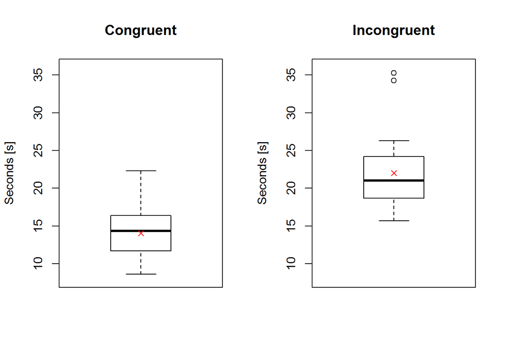

Although both distributions have comparable spread, the incongruent one has some high outliers and is clearly shifted towards higher times.

The following shows the histograms of the two distributions to get a picture of the detailed distribution of values.

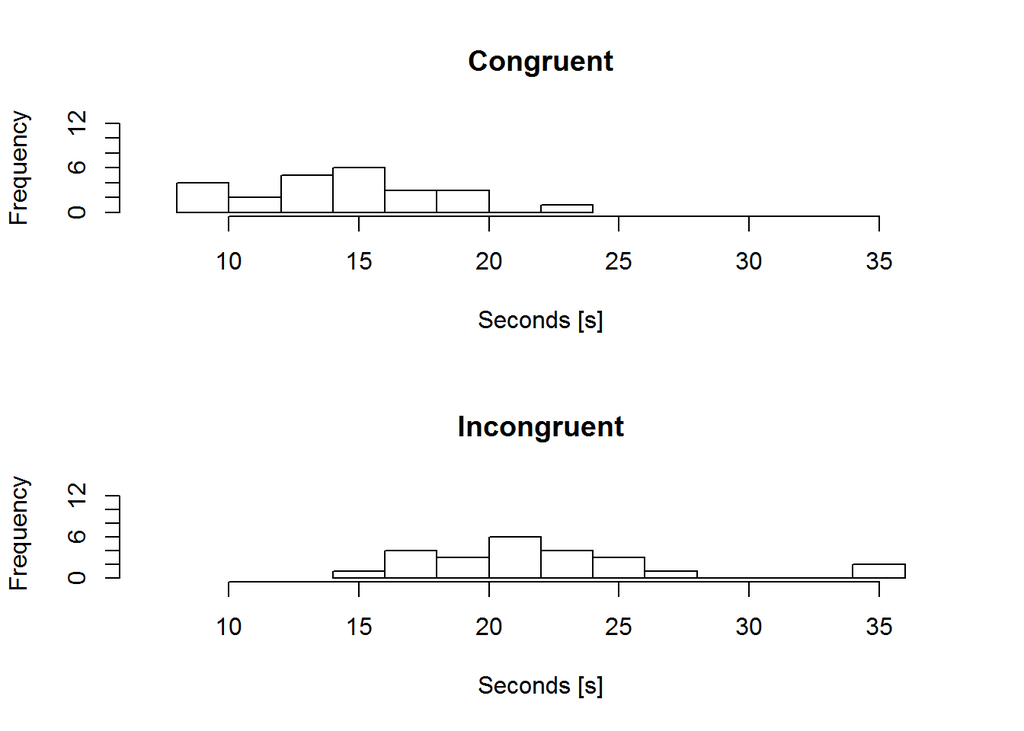

Both distributions look roughly normal or at least not skewed.

## Performing the t-test

Now it is time to actually perform the t-test. Since we are interested in the difference in means, regardless whether positive or negative, we choose the *two.sided* test. Since each observation of congruent and incongruent conditions is from one person, we set *paired = TRUE*.

```r
t.test(x = df$Congruent, y = df$Incongruent, alternative = "two.sided", paired = TRUE)
```

```
##
##  Paired t-test
##
## data:  df$Congruent and df$Incongruent
## t = -8.0207, df = 23, p-value = 4.103e-08
## alternative hypothesis: true difference in means is not equal to 0
## 95 percent confidence interval:
##  -10.019028  -5.910555
## sample estimates:
## mean of the differences
##               -7.964792
```

The *t-statistic* is $-8.0207$ and the *p-value* is way below $\alpha = 0.05$. Since the *critical t-value* is

```r
qt(p = 0.025, df=23)
```

```
## [1] -2.068658
```

we have *t-statistic < critical-t-value*. Thus we can reject the null hypothesis.

The $95\%$ confidence interval of the difference between the means is approximately $[-10.02, -5.91]$.

## Conclusion

Thus we can conclude that the mean time for the incongruent condition is different from the mean time for the congruent condition at significance level $\alpha = 0.05$.

## Remarks about potential causes

According to [1] and [2], there are several theories about the cause of this effect.

One popular theory is the so-called *automaticity model*. According to this theory, the reading of words is hard-wired and automatic while the recognition of colors is not automatic and requires effort.

A second theory suggests that reading words is not automatic, but faster than recognizing colors, thus the reading wins and makes recognition of the colors in the incongruent case more difficult. This theory is called the *speed of processing model*.

One possible variation of the experiment is as follows: replace the words of colors with words of objects related to colors. For example, sky is related to blue, snow related to white, fire related to red or yellow and so on. Thus in the congruent version, the word snow would be printed white (presumably on gray background) and the word sky would use blue ink. In the incongruent version, the word sky would maybe use the red ink.

## References

The following references were used for background information about the Stroop Effect.

[1] https://en.wikipedia.org/wiki/Stroop_effect

[2] https://www.rit.edu/cla/gssp400/sbackground.html